# Getting started with *landscapeDecoupler*

## What is in this vignette?

**Here you will find:**

1. **Introduction**
   - *A little about the concept*
2. **How to use it**
   - *Sequential decoupling*
   - *Specific decoupling*
3. **Compatibility with other packages**

## Introduction

Nested multiscale approaches constitute one of the main tools on the understanding ecological processes and detecting the scale of effect. However, nested approaches inherently retain both the effect and noise of the landscape attributes from the smaller scales as walking toward the larger ones. Therefore, analyzing decoupled scales might reveal detailed ecological responses to landscape context. The idea of decoupled multiscale approaches still poorly explored and the lack of tools specifically designed to deal with is one of the reasons. We designed the *landscapeDecoupler* to help researchers to achieve this as simple as possible.

### A little about the concept

The image bellow summarizes the main ideas about *coupled/decoupled* multiscale approaches. You may noticed that the “traditional” nested landscape approach always have the other scales inside it. So, one may be interested in see how composition and structure of each portion of the landscape can contribute to any variable responses. Therefore, users can either use a sequential decoupling landscape strategy (Figure 1, B) or cut out an specific scale and compare against the total (Figure 1, C and D).

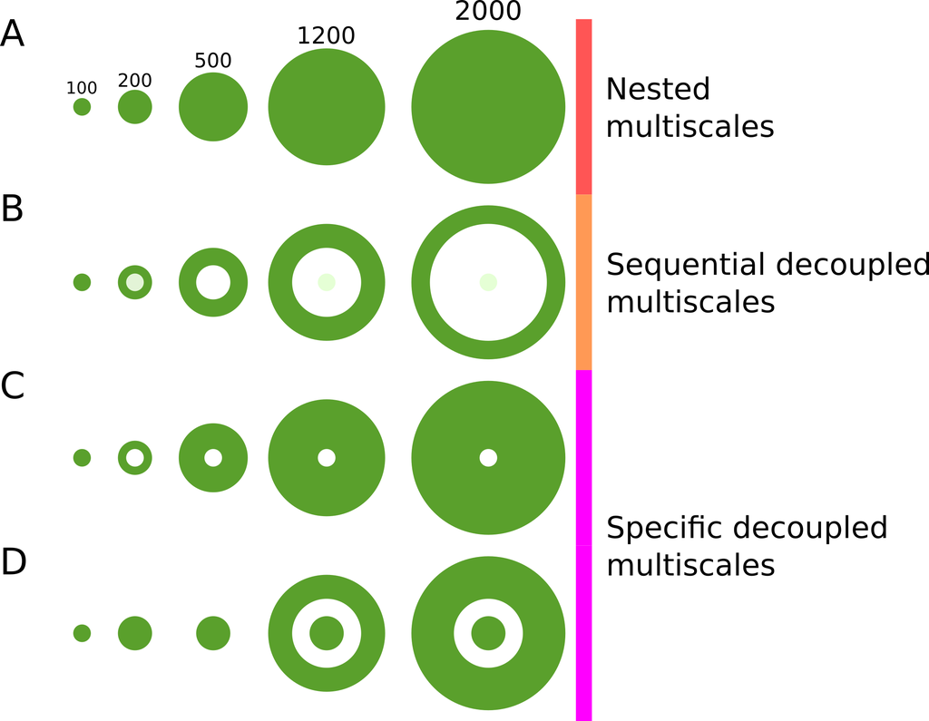

Figure 1. A summary of multiscale strategies

The idea of the LandscapeDecoupler is to recursively extract and analyze decoupled buffered scales from a given landscape, returning raster objects, files and basic metrics of the landscape components, so users can easily use rasters and metrics in further analysis.

The package needs three inputs:  
1. a classified landscape (a raster)  
2. lat-long coordinates (a txt or shape [.shp] file);  
3. two or more buffer sizes to be decoupled (input as vector).

The package also includes some conveniences to plot and export the results.